# Prepare analysis-ready data

Author

Florencia Grattarola

Published

September 12, 2024

R libraries

```r
library(sf)
sf::sf_use_s2(FALSE)
library(tidyverse)
```

## Data and countries

```r
countries <- st_read('data/latam.gpkg', quiet = T, layer='countries')
latam <- st_read('data/latam.gpkg', quiet = T, layer='latam')

PO <- read_csv('data/data_PO.csv')
PA <- read_csv('data/data_PA.csv')
```

## Presence-only grid-cells

### Create grid-cells

The size of each grid-cell is 100x100 km (100km=100000m)

```r
latam_grids <- st_make_grid(latam, 100000) %>%
  st_intersection(latam) %>%
  st_sf(gridID=1:length(.)) %>%
  st_set_geometry('geometry') %>%
  st_make_valid() %>% st_cast()
```

### Plot grid-cells

Empty, no species data yet.

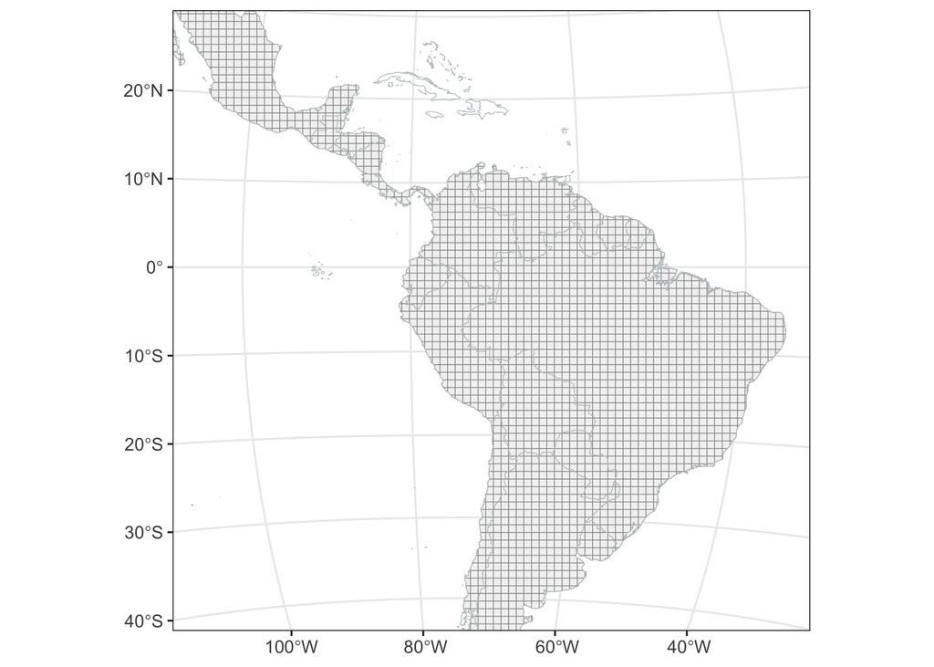

```r
ggplot() +
    geom_sf(data=latam_grids, fill='grey95', col='grey60') +
    geom_sf(data=countries, fill=NA, col='#bfc5c7', size=0.2) +
    coord_sf(xlim = c(-3500000, 4100000), ylim = c(-4400000, 3000000)) +
    theme_bw() +
    theme(text=element_text(size = 12))
```

### Calculate the number of records per grid-cell for each species

```r
data_PO <- PO %>%
  st_as_sf(coords=c('decimalLongitude', 'decimalLatitude')) %>%
  st_set_crs(4326) %>% st_transform(crs=st_crs(latam))

PO_time1 <- st_join(latam_grids, data_PO %>% filter(year<2014)) %>%
    group_by(gridID, scientificName) %>%
    summarise(NR=ifelse(n_distinct(scientificName, na.rm=T)!=0, n(), 0)) %>%
    pivot_wider(names_from = scientificName, names_sep = '_',
                values_from = NR, values_fill = 0) %>% select(-`NA`) %>%
    rename_with(., ~str_replace(., ' ', '_'))

PO_time2 <- st_join(latam_grids, data_PO %>% filter(year>=2014)) %>%
    group_by(gridID, scientificName) %>%
    summarise(NR=ifelse(n_distinct(scientificName, na.rm=T)!=0, n(), 0)) %>%
    pivot_wider(names_from = scientificName, names_sep = '_',
                values_from = NR, values_fill = 0) %>% select(-`NA`) %>%
    rename_with(., ~str_replace(., ' ', '_'))
```

### Save the grid-cells

```r
st_write(PO_time1, dsn='data/PO.gpkg', layer='time1')
st_write(PO_time2, dsn='data/PO.gpkg', layer='time2')
```

### Example plot: *Herpailurus yagouaroundi*

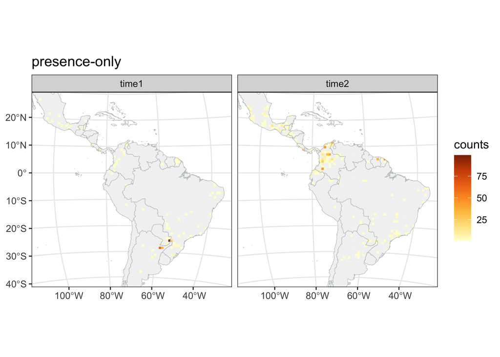

```r
data_PO_time1_time2 <- bind_rows(PO_time1 %>% mutate(period='time1'),
                                 PO_time2 %>% mutate(period='time2'))

ggplot() +
    geom_sf(data=data_PO_time1_time2 %>%
                mutate(Herpailurus_yagouaroundi=if_else(Herpailurus_yagouaroundi==0,
                                                        NA, Herpailurus_yagouaroundi)),
            aes(fill=Herpailurus_yagouaroundi), col=NA) +
    scale_fill_distiller(palette='YlOrBr', direction = 1, na.value = 'grey95')+
    geom_sf(data=countries, fill=NA, col='#bfc5c7', size=0.2) +
    facet_wrap(~period)+
    labs(title='presence-only', fill='counts') +
    coord_sf(xlim = c(-3500000, 4100000), ylim = c(-4400000, 3000000)) +
    theme_bw() +
    theme(text=element_text(size = 12))
```

## Presence-absence polygons

### Create polygons for time1 and time2 (according to the data at each period)

We first standardise area and effort units and split the data in the two time periods, summarising the records into individual surveys. Then we create a buffer area with the coordinates of each survey and the study’s area as buffer area. Finally, we aggregate overlapping polygons and combine them into single polygons. This is just empty polygons (their geometry).

```r
time1_period = interval(ymd('2000-01-01'), ymd('2013-12-31'))
time2_period = interval(ymd('2014-01-01'), today())

# standardise data to be in the same units for area and effort
PA <- PA %>%
  mutate(area_m2 = case_when(totalAreaSampledUnit == 'ha' ~ (totalAreaSampledValue * 10000),
                             totalAreaSampledUnit == 'km2' ~ (totalAreaSampledValue * 1000000),
                             totalAreaSampledUnit == 'm2' ~ totalAreaSampledValue,
                             .default = NA)) %>%
  mutate(effort_days = case_when(samplingEffortUnit == 'camera trap hours' ~ (samplingEffortValue / 24),
                                 .default = samplingEffortValue)) %>%
  mutate(span = interval(dateStart, dateEnd),
         independentLocation = str_c(decimalLatitude,':', decimalLongitude),
         independentYearSpan = str_c(year(dateStart),':', year(dateEnd)),
         period = case_when(span %within% time2_period ~ 'time2',
                            span %within% time1_period ~ 'time1',
                            .default = NA)) %>% filter(!is.na(period))

# keep all the point locations of the studies per each time period to make polygons
PA_allsites <- PA %>%
  select(recordID, dateStart, dateEnd, decimalLatitude, decimalLongitude,
         eventDurationValue, eventDurationUnit, eventDurationRemarks,
         samplingEffortValue, samplingEffortUnit, area_m2,
         independentLocation, independentYearSpan, period) %>%
  distinct(independentLocation, period, .keep_all = T) %>%
  sf::st_as_sf(coords=c('decimalLongitude', 'decimalLatitude')) %>%
  sf::st_set_crs(4326) %>% st_transform(crs=st_crs(latam))

# buffer the point locations with the area of the study to create polygons
PA_allsites_buff <- st_buffer(PA_allsites, sqrt(PA_allsites$area_m2/pi))

# aggregate overlapping polygons for each time period
blobs_time1 <- PA_allsites_buff %>% filter(period=='time1') %>%
  st_union() %>% st_cast('POLYGON') %>% st_sf('ID'= 1:length(.)) %>%
  st_set_geometry('geometry')
blobs_time2 <- PA_allsites_buff %>% filter(period=='time2') %>%
  st_union() %>% st_cast('POLYGON') %>% st_sf('ID'= 1:length(.)) %>%
  st_set_geometry('geometry')
```

### Plot polygons

Empty, no species data yet.

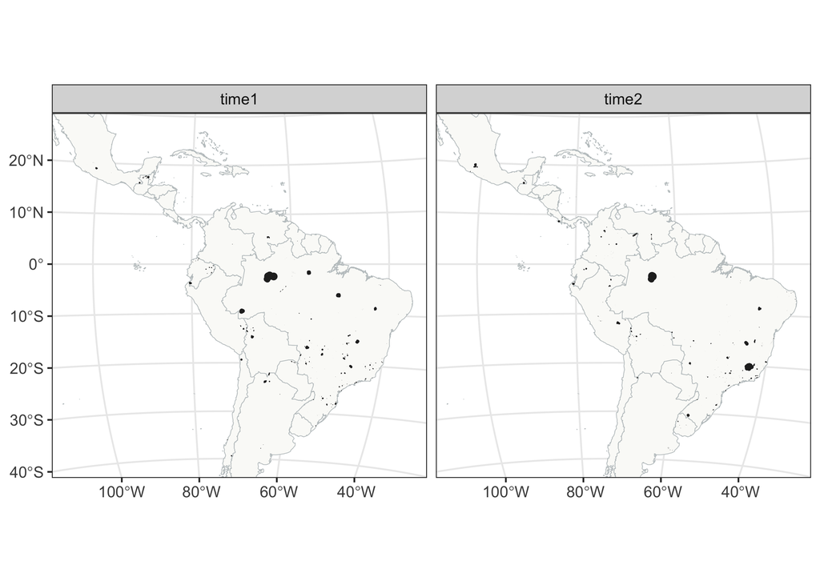

```r
blobs_time1_time2 <- bind_rows(blobs_time1 %>% mutate(period='time1'),
                               blobs_time2 %>% mutate(period='time2'))

ggplot() +
    geom_sf(data=countries, fill='#fafaf8', col='#bfc5c7', size=0.2) +
    geom_sf(data=blobs_time1_time2, fill='grey15', col=NA) +
    coord_sf(xlim = c(-3500000, 4100000), ylim = c(-4400000, 3000000)) +
    facet_wrap(~period) +
    theme_bw() +
    theme(text=element_text(size = 12))
```

### Calculate temporal span and effort in days for each **survey study** at each time period

For each individual survey we calculate the total temporal span and effort accounted for in the study.

```r
PA_allsites_effort_and_time  <- PA %>%
  select(recordID, dateStart, dateEnd, decimalLatitude, decimalLongitude,
         eventDurationValue, eventDurationUnit, eventDurationRemarks,
         samplingEffortValue, samplingEffortUnit, effort_days, area_m2,
         independentLocation, independentYearSpan, period) %>%
  group_by(independentLocation, independentYearSpan, area_m2) %>%
  summarise(effort=max(effort_days),
            period=paste(unique(period)),
            recordIDs=paste(unique(recordID), collapse = ';'),
            maxEndDate=max(dateEnd),
            minStartDate=min(dateStart)) %>%
  mutate(maxTemporalSpan= as.numeric(maxEndDate-minStartDate)) %>%
  mutate(decimalLatitude = as.numeric(word(independentLocation, 1, sep=':')),
         decimalLongitude = as.numeric(word(independentLocation, 2, sep=':')))

# make it a spatial object
PA_allsites_effort_and_time <- PA_allsites_effort_and_time %>%
  sf::st_as_sf(coords=c('decimalLongitude', 'decimalLatitude')) %>%
  sf::st_set_crs(4326) %>% st_transform(crs=st_crs(latam))
```

### Calculate temporal span and effort in days for each **polygon** at each time period

```r
# to calculate the effort in days for each blob, we need to differentiate the two periods
blobs_efforttime_time1 <- st_join(blobs_time1,
                            PA_allsites_effort_and_time %>% filter(period=='time1'),
                            left=TRUE)  %>%
  group_by(ID) %>%
  summarise(effort=sum(effort),
            temporalSpan=sum(maxTemporalSpan),
            recordIDs=paste(unique(recordIDs), collapse = ';')) %>%
  mutate(area=st_area(.))


blobs_efforttime_time2 <- st_join(blobs_time2,
                                PA_allsites_effort_and_time %>% filter(period=='time2'),
                                left=TRUE)  %>%
  group_by(ID) %>%
  summarise(effort=sum(effort),
            temporalSpan=sum(maxTemporalSpan),
            recordIDs=paste(unique(recordIDs), collapse = ';')) %>%
  mutate(area=st_area(.))
```

### Generate 0 (zeros) for each **survey study** where the species haven’t been recorded

For each study we then generate zeros where the species are not present (out of the total list of species recorded). In this way we assume presence=0 if a study did not detect the species.

```r
# This can very probably be done in a more efficient way, but this one works!
PA_0 <- PA %>% rename(effort=effort_days) %>%
  pivot_wider(names_from = scientificName,
              values_from = c(presence, effort),
              values_fill = c(list(presence=0),
                              list(effort=0))) %>%
  pivot_longer(cols=starts_with(c('presence_', 'effort_')),
               names_to=c('metric', 'scientificName'),
               names_sep='_') %>%
  pivot_wider(names_from = metric,
              values_from = value,
              values_fill = c(list(value=0))) %>%
  distinct(scientificName, independentYearSpan, independentLocation, presence, .keep_all = T) %>%
  group_by(scientificName, independentYearSpan, independentLocation) %>%
  mutate(presence=sum(presence),
         effort=max(effort))  %>%
  distinct(scientificName, independentYearSpan, independentLocation, .keep_all = T) %>%
  ungroup() %>%
  group_by(independentLocation, independentYearSpan) %>%
  mutate(effort=max(effort)) %>%
  ungroup()

# make it a spatial object
PA_0_sf <- PA_0 %>%
  sf::st_as_sf(coords=c('decimalLongitude', 'decimalLatitude')) %>%
  st_set_crs(4326) %>%
  st_transform(crs=st_crs(latam))
```

### Calculate presences/absence for each species at each polygon in each time period

To do this we create two functions, one that returns the presence/absence for each species at each polygon in time and another that does this recursively for all species.

```r
time1_period = interval(ymd('2000-01-01'), ymd('2013-12-31'))
time2_period = interval(ymd('2014-01-01'), today())

calculate_PA_sp_blobs <- function(PA, blobs, sp, time){

  df_period <- PA %>%
    filter(scientificName==sp & presence==1 & period == time) %>%
    select(scientificName, presence, period)

  df_period_blobs <- st_join(blobs, df_period,
                             left=TRUE, join = st_contains) %>%
    group_by(ID) %>%
    summarise(presence = max(presence),
              temporalSpan = max(temporalSpan),
              effort = max(effort),
              area = max(area)) %>%
    mutate(presence = ifelse(is.na(presence), 0, presence),
           period = time) %>% relocate(ID, period) %>%
  return(df_period_blobs)
}

calculate_PA_ALL_sp_blobs <- function(PA, blobs, sp_list, time) {

  sp_blobs <- blobs %>% select(ID, effort, temporalSpan, area) %>%
    mutate(period=time)

  for(sp in sp_list){
    PA_sp_time_blobs <- calculate_PA_sp_blobs(PA, blobs, sp, time) %>%
      mutate(species = str_replace(sp, ' ',  '_')) %>% select(species, presence) %>%
      pivot_wider(names_from = species, values_from = presence)

    sp_blobs <- st_join(sp_blobs, PA_sp_time_blobs)
  }
  return(sp_blobs)
}
```

And we run the function

```r
sp_list <- unique(PA_0_sf$scientificName)

PA_ALL_sp_blobs_time1 <- calculate_PA_ALL_sp_blobs(PA_0_sf, blobs_efforttime_time1, sp_list, 'time1')
PA_ALL_sp_blobs_time2 <- calculate_PA_ALL_sp_blobs(PA_0_sf, blobs_efforttime_time2, sp_list, 'time2')
```

### Save the polygons

```r
st_write(PA_ALL_sp_blobs_time1, dsn='data/PA.gpkg', layer='time1')
st_write(PA_ALL_sp_blobs_time2, dsn='data/PA.gpkg', layer='time2')
```

### Example plot: *Herpailurus yagouaroundi*

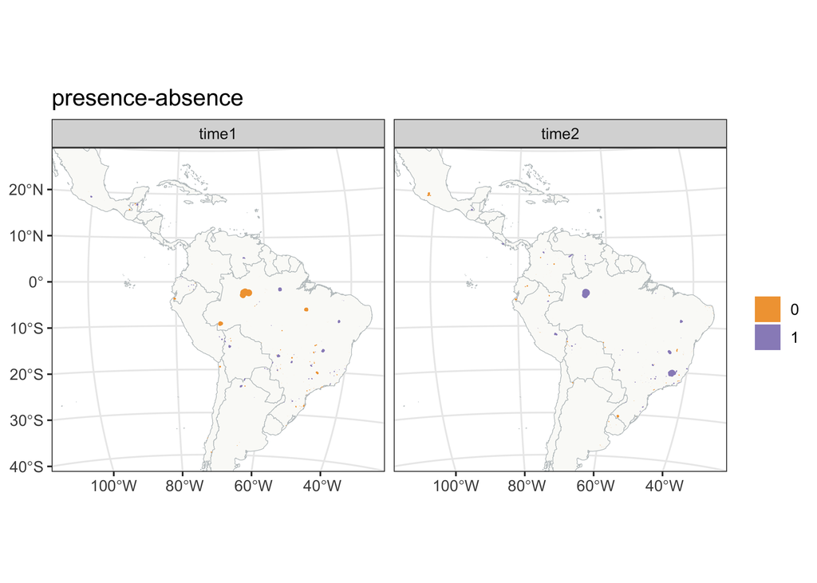

```r
PA_hyagouaroundi_time1_blobs <- PA_ALL_sp_blobs_time1 %>% select(c(1:6, Herpailurus_yagouaroundi))
PA_hyagouaroundi_time2_blobs <- PA_ALL_sp_blobs_time2 %>% select(c(1:6, Herpailurus_yagouaroundi))

data_PA_time1_time2 <- bind_rows(PA_hyagouaroundi_time1_blobs,PA_hyagouaroundi_time2_blobs)

ggplot() +
    geom_sf(data=countries, fill='#fafaf8', col='#bfc5c7', size=0.2) +
    geom_sf(data=data_PA_time1_time2,
            aes(fill=factor(Herpailurus_yagouaroundi)), col=NA) +
    scale_fill_manual(values = c('#f1a340','#998ec3'))+
    facet_wrap(~period)+
    labs(title='presence-absence', fill='') +
    coord_sf(xlim = c(-3500000, 4100000), ylim = c(-4400000, 3000000)) +
    theme_bw() +
    theme(text=element_text(size = 12))
```